# Tree height preference

Let’s figure out the preferred tree heights of our species. We’ll use a canopy height data layer and compare to the tree heights found in the iNaturalist home ranges of our species.

Set things up

```r
rm(list = ls())
library(tidyverse)
library(here)
```

First let’s look at some data on tree species heights from New Hampshire

Now bring in species data

```r
Trees<-read.csv(here("Data", "Trees", "tree_heights.csv"))
```

Add columns to convert to meters

```r
Trees<-Trees %>% mutate(
  Mean_ht_m = round(Mean_ht_ft*0.3048,1),
  sd_ht_m = round(sd_ht_ft*0.3048,1),
  min_ht_m = round(min_ht_ft*0.3048,1),
  max_ht_m = round(max_ht_ft*0.3048,1))
```

Now plot

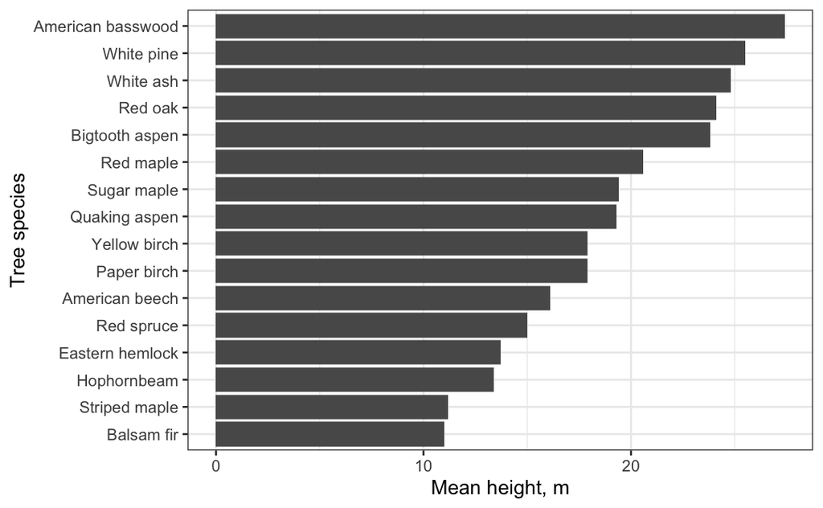

```r
Trees %>% arrange(Mean_ht_m) %>% ggplot(aes(reorder(Common.name,Mean_ht_m), Mean_ht_m))+
  geom_col()+
  coord_flip()+
  labs(x = "Tree species", y = "Mean height, m")+
  theme_bw()
```

Pull in the basic information from the tree height raster that we exported from ArcGIS pro.

```r
TH<-read.csv(here("Data", "Trees", "forest_height_data.csv"))
```

Now figure out the percent of the landscape made up of each tree height

```r
total_pixels<-sum(TH$COUNT)
TH<-TH %>% mutate(
                  Percent = round((100*(TH$COUNT/total_pixels)),2)
)
```

Now let’s look at a histogram of tree heights to see if there are natural breaks. We’ll ignore values of 0 and above 50.

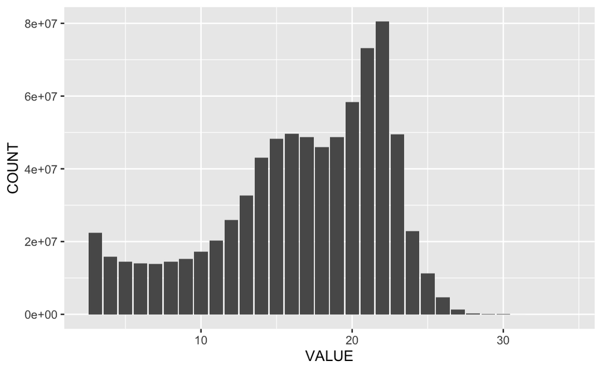

```r
TH %>% filter(VALUE > 0 & VALUE <= 50 ) %>% ggplot(aes(x = VALUE, y = COUNT))+
  geom_col()
```

So we’ll assign tree height as “none-short”, “low”, “medium”, and “tall” based on looking at this figure: none-short = up to 10m low = 11 to 13 m medium = 13 to 19 m tall = 20+ m

Write loop to go through and assign the category

```r
for(i in 1: length(TH$VALUE)){
  if (TH$VALUE[i] < 11){
    TH$ht_category[i] <- "none-short"
  }else if (TH$VALUE[i] > 10 & TH$VALUE[i] < 14){
    TH$ht_category[i] <- "low"
  } else if (TH$VALUE[i] > 13 & TH$VALUE[i] <20){
    TH$ht_category[i] <- "medium"
  } else if (TH$VALUE[i] >19 & TH$VALUE[i] < 40){
    TH$ht_category[i] <- "tall"
  } else {
    TH$ht_category[i] <- "NA"
  }
}
```

Now let’s look at the data for one of our species

```r
PLCI_ht<-read.csv(here("Data", "Trees", "PLCI_for_height.csv"))
```

Determine the number of pixels in each home range (Field1)

```r
STVA_sums<-STVA_ht %>% group_by(Field1) %>% summarise(
  Tot_pixels = sum(Count)
)
```

```r
STVA_ht<-left_join(STVA_ht, STVA_sums)
```

Now join tree_hts to STVA_ht

```r
STVA_ht<-left_join(STVA_ht, tree_hts)
```